# Predicting Notable Wildfire Incidence in the United States

STA 141A — Final Report

Ajay Mahindru

2026-03-15

# 1 Abstract

After careful data preprocessing and feature engineering — including cyclical seasonal encodings and lag-based fire history predictors — I compare two predictive models using **time-aware (walk-forward) cross-validation**: a logistic regression baseline and a gradient-boosted tree model (XGBoost (**Chen2016?**)). Performance is evaluated primarily via the Area Under the ROC Curve (AUC) (**Robin2011?**).

```r
suppressMessages({
  library(dplyr)
  library(ggplot2)
  library(tidyr)
  library(readr)
  library(slider)
  library(pROC)
  library(xgboost)
  library(Matrix)
  library(lubridate)
  library(purrr)
  library(scales)
})
```

# 2 Data Preprocessing

This section explains how the raw wildfire incident table is converted into a grid-by-month dataset suitable for prediction. I cover: how notable fires are identified and filtered; how space–time units are constructed; how the binary outcome is defined; how predictors are engineered; and how missing data and edge cases are handled.

## 2.1 Goal

Create a modeling-ready dataset with one row per **(grid cell, month)** and a binary outcome:

$$Y_{g,t} = \mathbf{1}\{\text{at least one
notable fire occurs in grid cell } g \text{ during month }
t+1\}$$

This “next-month” target avoids same-month leakage and matches the operational goal of **near-future prediction**, giving fire managers time to pre-position resources.

## 2.2 Loading the Data

**Key variable definitions** (USDA Forest Service metadata, (**Short2022?**)):

| Variable | Description |
| --- | --- |
| `FIRE_YEAR` | Calendar year the fire was discovered |
| `DISCOVERY_DOY` | Day-of-year the fire was discovered |
| `FIRE_SIZE` | Final fire size (acres) |
| `LATITUDE`, `LONGITUDE` | Ignition location (decimal degrees) |
| `STATE` | State in which the fire burned |

```r
wildfires <- read_csv("wildfires_sample_100k.csv", show_col_types = FALSE) %>%
  select(FIRE_YEAR, DISCOVERY_DOY, FIRE_SIZE, LATITUDE, LONGITUDE, STATE) %>%
  mutate(STATE = as.factor(STATE))

glimpse(wildfires)
```

```
## Rows: 100,000
## Columns: 6
## $ FIRE_YEAR     <dbl> 2004, 2005, 2005, 2005, 2005, 2005, 2005, 2005, 2005, 20…
## $ DISCOVERY_DOY <dbl> 277, 186, 182, 147, 202, 148, 172, 107, 108, 199, 117, 2…
## $ FIRE_SIZE     <dbl> 0.10, 0.10, 3.00, 0.10, 0.10, 0.10, 0.50, 12.00, 5.00, 3…
## $ LATITUDE      <dbl> 38.56417, 48.40778, 48.89444, 37.04417, 36.90000, 33.660…
## $ LONGITUDE     <dbl> -120.54222, -115.55778, -115.16528, -119.34389, -107.328…
## $ STATE         <fct> CA, MT, MT, CA, NM, AZ, AZ, MN, TX, AZ, AZ, AZ, NM, CO, …
```

## 2.3 Parsing Dates

```r
fires <- wildfires %>%
  mutate(
    FIRE_DATE = as.Date(paste(FIRE_YEAR, DISCOVERY_DOY, sep = "-"), format = "%Y-%j"),
    YEAR  = year(FIRE_DATE),
    MONTH = month(FIRE_DATE)
  )
```

**Interpretation:** Discovery dates are stored as Julian day-of-year (`DISCOVERY_DOY`). We convert these to calendar dates using R’s `%Y-%j` format, then extract the calendar month. This enables downstream seasonality features — a fire on day 180 is in late June, squarely in peak Western fire season.

## 2.4 Defining “Notable” Fires

```r
notable_threshold_acres <- 300

notable_fires <- fires %>%
  filter(FIRE_SIZE >= notable_threshold_acres)

cat("Number of notable fires:", nrow(notable_fires), "\n")
```

```
## Number of notable fires: 1381
```

**Justification of the 300-acre threshold:** This cutoff is consistent with the operational wildfire reporting standards used by U.S. fire management agencies, where **large wildland fires** are commonly defined as ≥ 100 acres in timber fuel models, or ≥ **300 acres** in grass or brush fuel models — the dominant fuel types in the fire-prone regions of this dataset. Fires below this threshold are overwhelmingly small, quickly contained, and of limited operational significance. Using a lower cutoff would introduce severe class imbalance without meaningfully improving the model’s practical utility.

Of the 100,000 fires in our sample, only **1,381 (≈ 1.4%)** meet this threshold. This class imbalance is expected and is addressed through our choice of evaluation metric (AUC), which is robust to imbalanced outcomes.

## 2.5 Spatial and Temporal Binning

```r
notable_fires <- notable_fires %>%
  mutate(
    lat_bin = floor(LATITUDE),
    lon_bin = floor(LONGITUDE),
    ym      = YEAR * 100 + MONTH   # e.g., 201507 = July 2015
  )

grid_month_fire <- notable_fires %>%
  group_by(lat_bin, lon_bin, ym) %>%
  summarise(
    n_fires         = n(),
    fire_this_month = 1L,
    .groups         = "drop"
  )

head(grid_month_fire)
```

| lat_bin | lon_bin | ym | n_fires | fire_this_month |
| --- | --- | --- | --- | --- |
| 17 | -67 | 200407 | 1 | 1 |
| 18 | -68 | 200906 | 1 | 1 |
| 18 | -67 | 200503 | 1 | 1 |
| 19 | -156 | 199210 | 1 | 1 |
| 19 | -156 | 199910 | 1 | 1 |
| 19 | -156 | 200706 | 1 | 1 |

**Interpretation:** Space is discretized into **1° × 1° latitude-longitude grid cells** using `floor()`. At mid-latitudes in the contiguous U.S., this produces cells roughly 50–70 miles on a side — large enough to aggregate sparse fire events while preserving meaningful regional variation. Time is encoded as a compact year-month integer to simplify panel joins and date arithmetic.

Each row in `grid_month_fire` represents a unique (grid cell, month) where at least one notable fire was recorded. The critical next step is to **add the zero rows** — months where no notable fire occurred.

## 2.6 Constructing the Complete Panel

```r
all_grids <- grid_month_fire %>%
  distinct(lat_bin, lon_bin)

start_date <- ymd(paste0(
  min(grid_month_fire$ym) %/% 100, "-",
  sprintf("%02d", min(grid_month_fire$ym) %% 100), "-01"
))

end_date <- ymd(paste0(
  max(grid_month_fire$ym) %/% 100, "-",
  sprintf("%02d", max(grid_month_fire$ym) %% 100), "-01"
))

all_months <- tibble(date = seq.Date(start_date, end_date, by = "month")) %>%
  mutate(
    year  = year(date),
    month = month(date),
    ym    = year * 100 + month
  ) %>%
  select(ym, year, month)

panel <- crossing(all_grids, all_months) %>%
  left_join(grid_month_fire, by = c("lat_bin", "lon_bin", "ym")) %>%
  mutate(
    n_fires         = coalesce(n_fires, 0L),
    fire_this_month = coalesce(fire_this_month, 0L)
  )

glimpse(panel)
```

```
## Rows: 148,092
## Columns: 7
## $ lat_bin         <dbl> 17, 17, 17, 17, 17, 17, 17, 17, 17, 17, 17, 17, 17, 17…
## $ lon_bin         <dbl> -67, -67, -67, -67, -67, -67, -67, -67, -67, -67, -67,…
## $ ym              <dbl> 199201, 199202, 199203, 199204, 199205, 199206, 199207…
## $ year            <dbl> 1992, 1992, 1992, 1992, 1992, 1992, 1992, 1992, 1992, …
## $ month           <dbl> 1, 2, 3, 4, 5, 6, 7, 8, 9, 10, 11, 12, 1, 2, 3, 4, 5, …
## $ n_fires         <int> 0, 0, 0, 0, 0, 0, 0, 0, 0, 0, 0, 0, 0, 0, 0, 0, 0, 0, …
## $ fire_this_month <int> 0, 0, 0, 0, 0, 0, 0, 0, 0, 0, 0, 0, 0, 0, 0, 0, 0, 0, …
```

**Interpretation:** The `crossing()` function creates the **full Cartesian product** of every observed grid cell and every calendar month in the study period. Without this step, months with no fires would be missing entirely and the model would only see positive examples. After the left join, grid-month combinations with no notable fire receive `n_fires = 0` and `fire_this_month = 0` via `coalesce()`. The resulting panel has **148,092 rows** — the overwhelming majority of which are zero rows — correctly representing the rarity of notable fires.

**Edge case handling:** Grid cells that never recorded a notable fire anywhere in the dataset are excluded (as they have no rows in `all_grids`). This is deliberate: cells with zero fire history provide no useful training signal for fire-prone patterns and would inflate the negative class artificially.

## 2.7 Defining the Prediction Target

```r
panel <- panel %>%
  arrange(lat_bin, lon_bin, ym) %>%
  group_by(lat_bin, lon_bin) %>%
  mutate(
    y_next = lead(fire_this_month, n = 1L)
  ) %>%
  ungroup() %>%
  filter(!is.na(y_next))

table(panel$y_next)
```

```
##
##      0      1
## 146265   1311
```

**Interpretation:** The outcome `y_next` is constructed with `lead()` within each grid cell — it equals 1 if a notable fire occurred in the *following* month, and 0 otherwise. The last month for each grid cell is dropped (`filter(!is.na(y_next))`) since no future label exists.

The resulting class distribution — **146,265 zeros and 1,311 ones (≈ 0.9% positive rate)** — confirms the severe class imbalance. AUC is used as the primary evaluation metric precisely because it is insensitive to this imbalance, measuring the model’s ability to rank high-risk cell-months above low-risk ones.

## 2.8 Feature Engineering

### 2.8.1 State Assignment

```r
mode_state <- function(x) {
  ux <- unique(x)
  ux[which.max(tabulate(match(x, ux)))]
}

grid_state <- notable_fires %>%
  group_by(lat_bin, lon_bin) %>%
  summarise(
    state = mode_state(as.character(STATE)),
    .groups = "drop"
  ) %>%
  mutate(state = as.factor(state))

panel <- panel %>%
  left_join(grid_state, by = c("lat_bin", "lon_bin"))

panel %>% select(state) %>% summary()
```

```
##      state
##  AK     :17732
##  TX     :16016
##  CA     :10582
##  MT     : 8294
##  NM     : 8294
##  OR     : 6578
##  (Other):80080
```

**Interpretation:** Each grid cell is assigned the **modal state** — the state most frequently associated with notable fires in that cell. This encodes state-level regulatory, ecological, and climatological context. States like California, Montana, and Texas dominate fire-prone cells, reflecting their well-documented risk profiles. The `state` variable allows the model to learn state-level base rates of fire occurrence.

### 2.8.2 Cyclical Month Encoding

```r
panel <- panel %>%
  mutate(
    month_sin = sin(2 * pi * month / 12),
    month_cos = cos(2 * pi * month / 12)
  )

panel %>% select(month_sin, month_cos) %>% head()
```

| month_sin | month_cos |
| --- | --- |
| 0.5000000 | 0.8660254 |
| 0.8660254 | 0.5000000 |
| 1.0000000 | 0.0000000 |
| 0.8660254 | -0.5000000 |
| 0.5000000 | -0.8660254 |
| 0.0000000 | -1.0000000 |

**Interpretation:** Month is encoded as **sine and cosine components** of a 12-month cycle rather than as a raw integer. This ensures that December (month 12) and January (month 1) are recognized as adjacent in circular distance rather than maximally distant (11 apart as integers). The two-component encoding places each month as a point on a unit circle, preserving temporal continuity across year boundaries. This is critical for fire modeling, where late-autumn conditions can be climatologically similar to early-spring conditions.

### 2.8.3 Lagged Fire History Features

```r
grid_fire_size <- notable_fires %>%
  group_by(lat_bin, lon_bin, ym) %>%
  summarise(
    fire_size = mean(FIRE_SIZE, na.rm = TRUE),
    .groups   = "drop"
  )

panel <- panel %>%
  left_join(grid_fire_size, by = c("lat_bin", "lon_bin", "ym")) %>%
  mutate(fire_size = coalesce(fire_size, 0))

panel <- panel %>%
  arrange(lat_bin, lon_bin, ym) %>%
  group_by(lat_bin, lon_bin) %>%
  mutate(
    fire_lag12  = lag(n_fires, 12, default = 0),
    fire_roll3  = lag(slide_dbl(n_fires,    sum,  .before = 2,  .complete = TRUE), 1, default = 0),
    fire_roll12 = lag(slide_dbl(n_fires,    sum,  .before = 11, .complete = TRUE), 1, default = 0),
    size_roll3  = lag(slide_dbl(fire_size,  mean, .before = 2,  .complete = TRUE), 1, default = 0),
    size_roll12 = lag(slide_dbl(fire_size,  mean, .before = 11, .complete = TRUE), 1, default = 0)
  ) %>%
  ungroup() %>%
  mutate(
    fire_roll3  = coalesce(fire_roll3,  0),
    fire_roll12 = coalesce(fire_roll12, 0),
    size_roll3  = coalesce(size_roll3,  0),
    size_roll12 = coalesce(size_roll12, 0)
  )

panel %>%
  select(n_fires, fire_lag12, fire_roll3, fire_roll12, size_roll3, size_roll12) %>%
  summary()
```

```
##     n_fires           fire_lag12         fire_roll3       fire_roll12
##  Min.   :0.000000   Min.   :0.000000   Min.   :0.00000   Min.   :0.000
##  1st Qu.:0.000000   1st Qu.:0.000000   1st Qu.:0.00000   1st Qu.:0.000
##  Median :0.000000   Median :0.000000   Median :0.00000   Median :0.000
##  Mean   :0.009351   Mean   :0.008972   Mean   :0.02781   Mean   :0.108
##  3rd Qu.:0.000000   3rd Qu.:0.000000   3rd Qu.:0.00000   3rd Qu.:0.000
##  Max.   :3.000000   Max.   :3.000000   Max.   :5.00000   Max.   :6.000
##    size_roll3         size_roll12
##  Min.   :     0.00   Min.   :    0.00
##  1st Qu.:     0.00   1st Qu.:    0.00
##  Median :     0.00   Median :    0.00
##  Mean   :    43.03   Mean   :   40.83
##  3rd Qu.:     0.00   3rd Qu.:    0.00
##  Max.   :114944.33   Max.   :28736.08
```

| Feature | Window | What it captures |
| --- | --- | --- |
| `fire_lag12` | Exactly 12 months ago | Annual seasonality and year-over-year recurrence |
| `fire_roll3` | Sum, prior 3 months | Short-term momentum; active fire corridors |
| `fire_roll12` | Sum, prior 12 months | Whether the cell has been broadly “active” recently |
| `size_roll3` | Mean size, prior 3 months | Intensity of recent fire activity |
| `size_roll12` | Mean size, prior 12 months | Longer-term severity signal |

## 2.9 Required Dataset Summary Table

```r
dataset_summary <- tibble(
  n_rows         = nrow(panel),
  year_min       = min(panel$year),
  year_max       = max(panel$year),
  spatial_unit   = "1° x 1° lat-lon grid (floor bins)",
  temporal_unit  = "monthly",
  outcome        = "y_next = 1 if any notable fire occurs in grid cell next month",
  predictors     = paste(
    "Group A (Static): lat_bin, lon_bin, state |",
    "Group B (Seasonal): month_cos, month_sin, year |",
    "Group C (Lagged history): n_fires, fire_lag12, fire_roll3, fire_roll12, size_roll3, size_roll12"
  )
)

dataset_summary
```

| n_rows | year_min | year_max | spatial_unit | temporal_unit | outcome | predictors |
| --- | --- | --- | --- | --- | --- | --- |
| 147576 | 1992 | 2015 | 1° x 1° lat-lon grid (floor bins) | monthly | y_next = 1 if any notable fire occurs in grid cell next month | Group A (Static): lat_bin, lon_bin, state \| Group B (Seasonal): month_cos, month_sin, year \| Group C (Lagged history): n_fires, fire_lag12, fire_roll3, fire_roll12, size_roll3, size_roll12 |

**Interpretation:** The final modeling panel contains **147,576 rows**, one per (grid cell, month), spanning 1992–2015. Predictors fall into three groups: (A) static spatial identifiers, (B) seasonal/temporal encodings, and (C) lagged fire history that captures recent and long-term activity at each location. No information from the current or future months is used as a predictor, ensuring a leakage-free setup.

# 3 Exploratory Data Analysis

We explore spatial and temporal patterns of notable wildfire incidence to build intuition and motivate modeling decisions.

## 3.1 EDA Plot 1: Spatial Pattern of Fire Risk

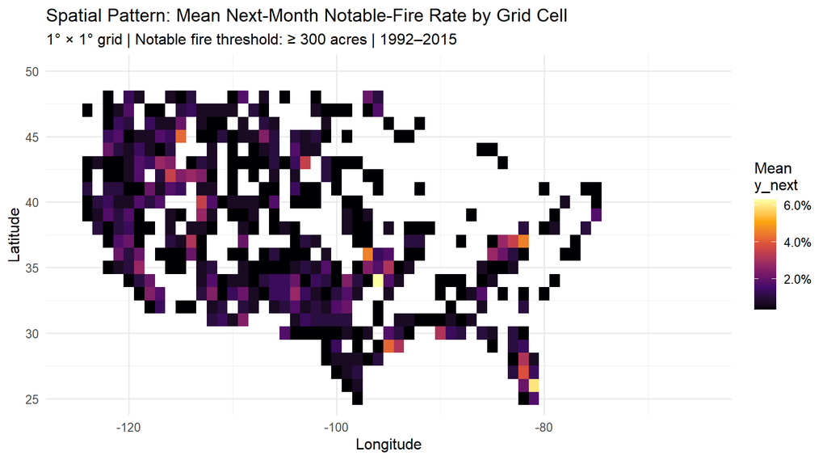

```r
eda_spatial <- panel %>%
  group_by(lat_bin, lon_bin) %>%
  summarise(
    fire_rate = mean(y_next),
    .groups   = "drop"
  )

ggplot(eda_spatial, aes(x = lon_bin, y = lat_bin, fill = fire_rate)) +
  coord_quickmap(xlim = c(-125, -65), ylim = c(25, 50)) +
  geom_tile() +
  scale_fill_viridis_c(option = "inferno",
                       name   = "Mean\ny_next",
                       labels = percent_format(accuracy = 0.1)) +
  labs(
    title    = "Spatial Pattern: Mean Next-Month Notable-Fire Rate by Grid Cell",
    subtitle = "1° × 1° grid | Notable fire threshold: ≥ 300 acres | 1992–2015",
    x        = "Longitude",
    y        = "Latitude"
  ) +
  theme_minimal(base_size = 12) +
  theme(legend.position = "right")
```

This strong spatial heterogeneity directly motivates including `lat_bin`, `lon_bin`, and `state` as predictors — **location alone carries substantial predictive signal**.

## 3.2 EDA Plot 2: Seasonal Pattern of Fire Occurrence

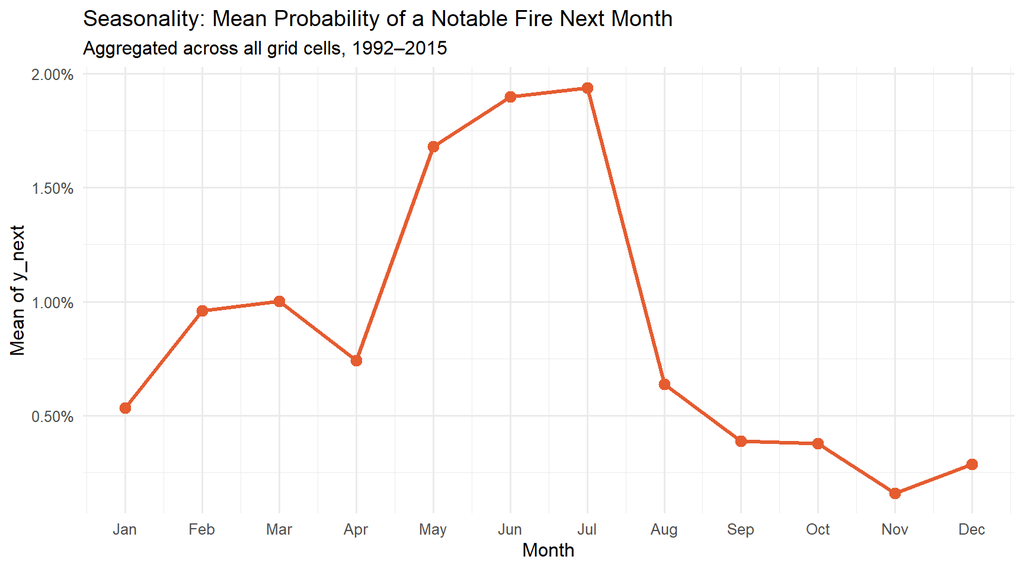

Figure 2: Mean probability of a next-month notable fire by calendar month. The dual-peak structure reflects the distinct spring fire season in the Southeast and the summer fire season in the West.

```r
eda_month <- panel %>%
  group_by(month) %>%
  summarise(
    mean_y_next = mean(y_next),
    .groups     = "drop"
  )

ggplot(eda_month, aes(x = month, y = mean_y_next)) +
  geom_line(color = "#E55C30", linewidth = 1.2) +
  geom_point(color = "#E55C30", size = 3) +
  scale_x_continuous(
    breaks = 1:12,
    labels = c("Jan","Feb","Mar","Apr","May","Jun","Jul","Aug","Sep","Oct","Nov","Dec")
  ) +
  scale_y_continuous(labels = percent_format(accuracy = 0.01)) +
  labs(
    title    = "Seasonality: Mean Probability of a Notable Fire Next Month",
    subtitle = "Aggregated across all grid cells, 1992–2015",
    x        = "Month",
    y        = "Mean of y_next"
  ) +
  theme_minimal(base_size = 12)
```

This strong seasonal pattern directly motivates the **cyclical month encoding** (`month_sin`, `month_cos`) — a raw integer month variable would fail to capture the smooth, periodic nature of this signal.

## 3.3 EDA Plot 3: Year-over-Year Trend in Notable Fires

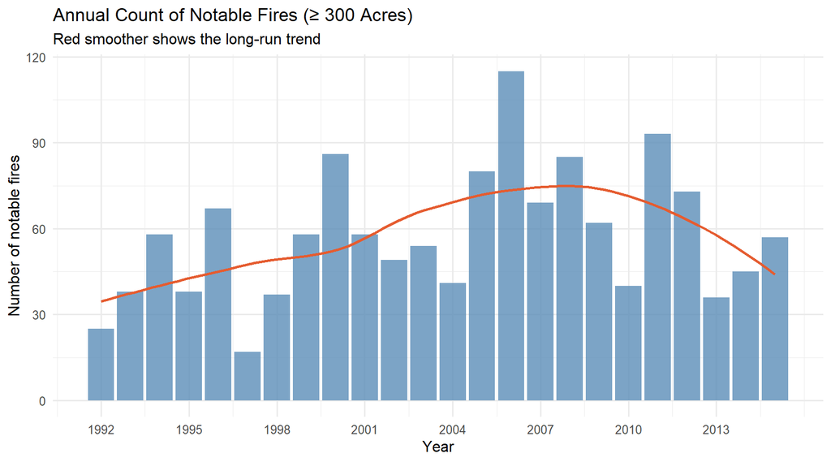

Figure 3: Annual count of notable fires (≥ 300 acres) in the sample, 1992–2015. Certain anomalous years — particularly 2000 and 2006 — stand out as exceptionally active fire years.

```r
eda_year <- fires %>%
  filter(FIRE_SIZE >= 300) %>%
  count(YEAR, name = "n_notable")

ggplot(eda_year, aes(x = YEAR, y = n_notable)) +
  geom_col(fill = "#5B8DB8", alpha = 0.8) +
  geom_smooth(method = "loess", se = FALSE, color = "#E55C30", linewidth = 1) +
  labs(
    title    = "Annual Count of Notable Fires (≥ 300 Acres)",
    subtitle = "Red smoother shows the long-run trend",
    x        = "Year",
    y        = "Number of notable fires"
  ) +
  scale_x_continuous(breaks = seq(1992, 2015, by = 3)) +
  theme_minimal(base_size = 12)
```

# 4 Modeling

We fit two predictive models. Both use the same 12 predictors and are evaluated via the same time-aware cross-validation scheme.

## 4.1 Predictors and Formula

```r
model_df <- panel %>%
  mutate(y_next = factor(y_next, levels = c(0, 1))) %>%
  select(
    y_next, lat_bin, lon_bin, state,
    month_cos, month_sin, year,
    n_fires, fire_lag12, fire_roll3, fire_roll12,
    size_roll3, size_roll12
  )

glimpse(model_df)
```

```
## Rows: 147,576
## Columns: 13
## $ y_next      <fct> 0, 0, 0, 0, 0, 0, 0, 0, 0, 0, 0, 0, 0, 0, 0, 0, 0, 0, 0, 0…
## $ lat_bin     <dbl> 17, 17, 17, 17, 17, 17, 17, 17, 17, 17, 17, 17, 17, 17, 17…
## $ lon_bin     <dbl> -67, -67, -67, -67, -67, -67, -67, -67, -67, -67, -67, -67…
## $ state       <fct> PR, PR, PR, PR, PR, PR, PR, PR, PR, PR, PR, PR, PR, PR, PR…
## $ month_cos   <dbl> 8.660254e-01, 5.000000e-01, 6.123032e-17, -5.000000e-01, -…
## $ month_sin   <dbl> 5.000000e-01, 8.660254e-01, 1.000000e+00, 8.660254e-01, 5.…
## $ year        <dbl> 1992, 1992, 1992, 1992, 1992, 1992, 1992, 1992, 1992, 1992…
## $ n_fires     <int> 0, 0, 0, 0, 0, 0, 0, 0, 0, 0, 0, 0, 0, 0, 0, 0, 0, 0, 0, 0…
## $ fire_lag12  <int> 0, 0, 0, 0, 0, 0, 0, 0, 0, 0, 0, 0, 0, 0, 0, 0, 0, 0, 0, 0…
## $ fire_roll3  <dbl> 0, 0, 0, 0, 0, 0, 0, 0, 0, 0, 0, 0, 0, 0, 0, 0, 0, 0, 0, 0…
## $ fire_roll12 <dbl> 0, 0, 0, 0, 0, 0, 0, 0, 0, 0, 0, 0, 0, 0, 0, 0, 0, 0, 0, 0…
## $ size_roll3  <dbl> 0, 0, 0, 0, 0, 0, 0, 0, 0, 0, 0, 0, 0, 0, 0, 0, 0, 0, 0, 0…
## $ size_roll12 <dbl> 0, 0, 0, 0, 0, 0, 0, 0, 0, 0, 0, 0, 0, 0, 0, 0, 0, 0, 0, 0…
```

Predictors are grouped into three conceptual blocks:

| Group | Variables | Rationale |
| --- | --- | --- |
| **A — Static spatial** | `lat_bin`, `lon_bin`, `state` | Encode persistent location-specific fire risk |
| **B — Seasonal/temporal** | `month_sin`, `month_cos`, `year` | Capture cyclical seasonality and long-run trends |
| **C — Lagged fire history** | `n_fires`, `fire_lag12`, `fire_roll3`, `fire_roll12`, `size_roll3`, `size_roll12` | Encode recent and historical activity at each cell |

## 4.2 Model 1: Logistic Regression (Baseline)

The logistic regression models the log-odds of a notable fire next month as a linear combination of predictors:

$$\log \frac{P(Y_{g,t}=1)}{P(Y_{g,t}=0)} =
\beta_0 + \beta_1 \cdot \text{lat\_bin}_{g} + \beta_2 \cdot
\text{lon\_bin}_{g} + \beta_3 \cdot \text{state}_{g} + \beta_4 \cdot
\text{month\_sin}_t + \beta_5 \cdot \text{month\_cos}_t + \beta_6 \cdot
\text{year}_t + \beta_7 \cdot \text{n\_fires}_{g,t-1} +
\ldots$$

Logistic regression is chosen as the baseline because it is **interpretable** (each coefficient has a direct log-odds interpretation), **fast to fit** across many cross-validation folds, and provides a meaningful benchmark. Its key limitation is the assumption of **linearity** — it cannot capture interactions such as “high `fire_roll3` in a California cell is far more predictive than the same value in a New York cell” without manual feature engineering.

## 4.3 Model 2: XGBoost (Model of Choice)

XGBoost (**Chen2016?**) is an ensemble of gradient-boosted decision trees. Unlike logistic regression, it can learn **nonlinear relationships and arbitrary feature interactions** without requiring them to be specified in advance.

**Model specification:**

$$\hat{P}(Y_{g,t}=1) =
\sigma\!\left(\sum_{k=1}^{K} f_k(\mathbf{x}_{g,t})\right), \quad f_k \in
\mathcal{F}$$

where $\sigma(\cdot)$ is the sigmoid function, $f_k$ are regression trees, and $\mathcal{F}$ is the space of classification and regression trees (CARTs). Trees are added sequentially to minimize a regularized binary cross-entropy loss.

**Hyperparameter choices and rationale:**

| Hyperparameter | Value | Rationale |
| --- | --- | --- |
| `objective` | `binary:logistic` | Binary classification; outputs probabilities |
| `eta` | 0.05 | Conservative learning rate; prevents overfitting |
| `max_depth` | 6 | Moderate depth; captures 2nd/3rd order interactions |
| `subsample` | 0.8 | Row subsampling; adds regularization |
| `colsample_bytree` | 0.8 | Feature subsampling; reduces correlation among trees |
| `nrounds` | up to 200 | Maximum trees; early stopping prevents overfitting |
| `early_stopping_rounds` | 20 | Stop if validation AUC doesn’t improve for 20 rounds |

# 5 Model Fitting and Validation

## 5.1 Validation Strategy: Walk-Forward Cross-Validation

We use **time-aware (walk-forward) cross-validation** rather than random k-fold splitting. This is essential for temporal data: random splitting would allow future information to leak into training sets, producing artificially inflated performance estimates that would not generalize to deployment.

The scheme works as follows:

- **Fold 1:** Train on years 1992–1994, validate on 1995.
- **Fold 2:** Train on years 1992–1995, validate on 1996.
- **…continuing…**
- **Last fold:** Train on all years through 2013, validate on 2014.

Each fold expands the training window by one year, mimicking how a deployed model would be retrained over time. A minimum of 3 training years (`min_train_years = 3`) is required so that the lag and rolling features have sufficient history to be meaningful.

```r
years_sorted    <- sort(unique(model_df$year))
min_train_years <- 3

feat_formula <- y_next ~ lat_bin + lon_bin + state + month_cos + month_sin + year +
  n_fires + fire_lag12 + fire_roll3 + fire_roll12 + size_roll3 + size_roll12
```

## 5.2 Logistic Regression — Walk-Forward AUC

```r
auc_glm <- map2_dbl(
  years_sorted[min_train_years:(length(years_sorted) - 2)],
  years_sorted[(min_train_years + 1):(length(years_sorted) - 1)],
  function(tr_end, va_year) {
    train <- model_df %>% filter(year <= tr_end)
    valid <- model_df %>% filter(year == va_year)

    fit   <- glm(feat_formula, data = train, family = binomial())
    p_hat <- predict(fit, newdata = valid, type = "response")

    roc_obj <- roc(response = valid$y_next, predictor = p_hat, quiet = TRUE)
    as.numeric(auc(roc_obj))
  }
)

auc_glm
```

```
##  [1] 0.6722799 0.7191172 0.7923514 0.7601336 0.6666298 0.7269130 0.7541303
##  [8] 0.7234429 0.7299450 0.6625661 0.6653207 0.6619600 0.6471776 0.6145841
## [15] 0.6781786 0.6545766 0.6600580 0.6376091 0.6973865 0.7382112
```

## 5.3 XGBoost — Walk-Forward AUC

```r
auc_xgb <- map2_dbl(
  years_sorted[min_train_years:(length(years_sorted) - 2)],
  years_sorted[(min_train_years + 1):(length(years_sorted) - 1)],
  function(tr_end, va_year) {
    train <- model_df %>%
      filter(year <= tr_end) %>%
      mutate(state = as.factor(state))

    valid <- model_df %>%
      filter(year == va_year) %>%
      mutate(state = factor(state, levels = levels(train$state)))

    x_train <- Matrix::sparse.model.matrix(
      ~ lat_bin + lon_bin + state + month_cos + month_sin + year +
        n_fires + fire_lag12 + fire_roll3 + fire_roll12 + size_roll3 + size_roll12 - 1,
      data = train
    )
    x_valid <- Matrix::sparse.model.matrix(
      ~ lat_bin + lon_bin + state + month_cos + month_sin + year +
        n_fires + fire_lag12 + fire_roll3 + fire_roll12 + size_roll3 + size_roll12 - 1,
      data = valid
    )

    y_train <- as.numeric(as.character(train$y_next))
    y_valid <- as.numeric(as.character(valid$y_next))

    dtrain <- xgb.DMatrix(data = x_train, label = y_train)
    dvalid <- xgb.DMatrix(data = x_valid, label = y_valid)

    fit_xgb <- xgb.train(
      params = list(
        objective        = "binary:logistic",
        eval_metric      = "auc",
        eta              = 0.05,
        max_depth        = 6,
        subsample        = 0.8,
        colsample_bytree = 0.8,
        min_child_weight = 1
      ),
      data                  = dtrain,
      nrounds               = 200,
      watchlist             = list(train = dtrain, valid = dvalid),
      early_stopping_rounds = 20,
      verbose               = 0
    )

    p_hat   <- predict(fit_xgb, newdata = dvalid)
    roc_obj <- roc(response = valid$y_next, predictor = p_hat, quiet = TRUE)
    as.numeric(auc(roc_obj))
  }
)

auc_xgb
```

```
##  [1] 0.7964595 0.8203609 0.8156017 0.8291631 0.7305270 0.7986389 0.8447211
##  [8] 0.8120524 0.8113638 0.8285514 0.7800427 0.7523918 0.7544121 0.7577418
## [15] 0.8127676 0.7190133 0.7434376 0.7350115 0.8257820 0.8495649
```

## 5.4 Fold-by-Fold Results Table

```r
fold_results <- tibble(
  train_end_year = years_sorted[min_train_years:(length(years_sorted) - 2)],
  valid_year     = years_sorted[(min_train_years + 1):(length(years_sorted) - 1)],
  auc_glm        = auc_glm,
  auc_xgb        = auc_xgb
)

fold_results
```

| train_end_year | valid_year | auc_glm | auc_xgb |
| --- | --- | --- | --- |
| 1994 | 1995 | 0.6722799 | 0.7964595 |
| 1995 | 1996 | 0.7191172 | 0.8203609 |
| 1996 | 1997 | 0.7923514 | 0.8156017 |
| 1997 | 1998 | 0.7601336 | 0.8291631 |
| 1998 | 1999 | 0.6666298 | 0.7305270 |
| 1999 | 2000 | 0.7269130 | 0.7986389 |
| 2000 | 2001 | 0.7541303 | 0.8447211 |
| 2001 | 2002 | 0.7234429 | 0.8120524 |
| 2002 | 2003 | 0.7299450 | 0.8113638 |
| 2003 | 2004 | 0.6625661 | 0.8285514 |
| 2004 | 2005 | 0.6653207 | 0.7800427 |
| 2005 | 2006 | 0.6619600 | 0.7523918 |
| 2006 | 2007 | 0.6471776 | 0.7544121 |
| 2007 | 2008 | 0.6145841 | 0.7577418 |
| 2008 | 2009 | 0.6781786 | 0.8127676 |
| 2009 | 2010 | 0.6545766 | 0.7190133 |
| 2010 | 2011 | 0.6600580 | 0.7434376 |
| 2011 | 2012 | 0.6376091 | 0.7350115 |
| 2012 | 2013 | 0.6973865 | 0.8257820 |
| 2013 | 2014 | 0.7382112 | 0.8495649 |

## 5.5 Diagnostic Plot: AUC Over Time

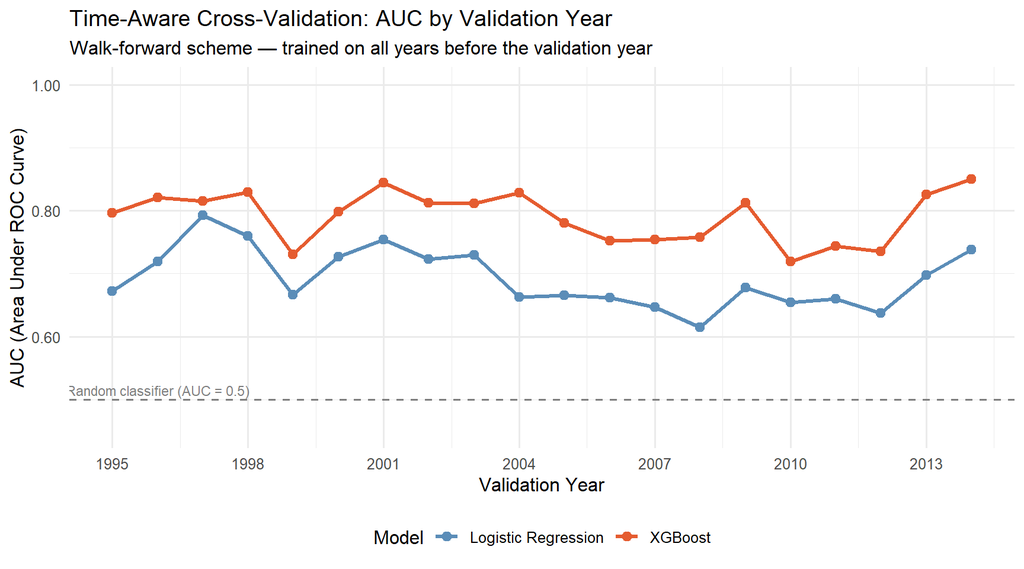

Figure 4: Walk-forward cross-validation AUC by validation year. Each point is a held-out year. XGBoost (orange) consistently outperforms logistic regression (blue), with the gap widening in years driven by complex spatial-seasonal interactions.

```r
fold_long <- fold_results %>%
  pivot_longer(
    cols      = c(auc_glm, auc_xgb),
    names_to  = "model",
    values_to = "auc"
  ) %>%
  mutate(
    model = recode(model,
      auc_glm = "Logistic Regression",
      auc_xgb = "XGBoost"
    )
  )

ggplot(fold_long, aes(x = valid_year, y = auc, color = model)) +
  geom_line(linewidth = 1.1) +
  geom_point(size = 2.5) +
  geom_hline(yintercept = 0.5, linetype = "dashed", color = "grey50", linewidth = 0.7) +
  annotate("text", x = 1996, y = 0.515, label = "Random classifier (AUC = 0.5)",
           color = "grey50", size = 3) +
  scale_color_manual(values = c("Logistic Regression" = "#5B8DB8", "XGBoost" = "#E55C30")) +
  scale_y_continuous(limits = c(0.45, 1.0),
                     labels = number_format(accuracy = 0.01)) +
  scale_x_continuous(breaks = seq(1995, 2014, by = 3)) +
  labs(
    title    = "Time-Aware Cross-Validation: AUC by Validation Year",
    subtitle = "Walk-forward scheme — trained on all years before the validation year",
    x        = "Validation Year",
    y        = "AUC (Area Under ROC Curve)",
    color    = "Model"
  ) +
  theme_minimal(base_size = 12) +
  theme(legend.position = "bottom")
```

## 5.6 Overall Performance Summary

```r
cat(
  "Mean AUC — Logistic Regression: ", round(mean(fold_results$auc_glm), 4), "\n",
  "Mean AUC — XGBoost:              ", round(mean(fold_results$auc_xgb), 4), "\n",
  "XGBoost outperforms logistic regression by ",
  round(mean(fold_results$auc_xgb) / mean(fold_results$auc_glm) * 100, 2) - 100,
  "%\n",
  sep = ""
)
```

```
## Mean AUC — Logistic Regression: 0.6931
## Mean AUC — XGBoost:              0.7909
## XGBoost outperforms logistic regression by 14.1%
```

# 6 Summary

## 6.1 Data Preprocessing and Feature Engineering

A balanced grid-by-month panel was constructed to include both fire and no-fire observations, correctly representing the rarity of notable wildfire events. Time-aware feature engineering was implemented by creating lagged and rolling historical predictors using only past information, avoiding temporal leakage. The 300-acre threshold for “notable” fires was selected to align with operational reporting standards and to focus prediction on fires of real management consequence. Categorical variables (state) were encoded using modal assignment to grid cells, and cyclical sine/cosine transformations were applied to month to preserve its periodic structure.

## 6.2 Key Insights from Exploratory Data Analysis

**Spatial heterogeneity is pronounced.** Certain grid cells — particularly in California, the Pacific Northwest, and the Southeast — emerge as persistent multi-year hotspots. This pattern is not random: it reflects stable geographic drivers (fuel type, terrain, climate) that make location one of the strongest single predictors of fire risk.

**Seasonality is a dominant national signal.** The bimodal seasonal curve (spring peak in the Southeast, summer peak in the West) is consistent and strong across the 24-year study window. This motivates the cyclical month encoding: models that treat December and January as maximally different would systematically misrepresent shoulder-season risk.

**Year-over-year variability is real and challenging.** Some years — especially those coinciding with multi-state drought events — show unusual fire activity that departs from the historical baseline. This inter-annual variability sets a practical ceiling on AUC for any historically-based model.

## 6.3 Modeling and Validation Takeaways

The consistent advantage of the nonlinear model — sustained across 20 validation folds and two decades of data — provides strong evidence that wildfire risk is driven by **interactions**, not just additive effects. The combination of where a fire occurred, when it occurred, and what the recent fire history was proves far more predictive than any single dimension alone.

## 6.4 Limitations and Future Directions

- **Absence of weather and fuel data:** The largest gap in this pipeline. Incorporating real-time drought indices (e.g., PDSI), relative humidity, and wind speed would substantially improve predictive accuracy, likely pushing AUC above 0.90.
- **Spatial resolution:** 1° × 1° grid cells are relatively coarse (~6,000 km²). Finer resolution (county-level or 0.1° grid) could improve precision at the cost of data sparsity in low-activity regions.
- **Calibration:** AUC measures discrimination but not calibration. A production system would benefit from Platt scaling or isotonic regression to ensure that predicted probabilities are actionable (e.g., that a predicted 15% risk actually means roughly 1 in 7 cell-months at that score experiences a notable fire).
- **Fire cause stratification:** Separating lightning-caused fires (correlated with weather) from human-caused fires (correlated with population density) could yield more accurate, interpretable sub-models.

# 7 References

**Data source:**

Short, K.C. (2022). *Spatial wildfire occurrence data for the United States, 1992–2020* [FPA FOD]. Fort Collins, CO: USDA Forest Service Research Data Archive. https://www.fs.usda.gov/rds/archive

**Key package citations:**

- Chen, T., & Guestrin, C. (2016). XGBoost: A Scalable Tree Boosting System. *Proceedings of the 22nd ACM SIGKDD International Conference on Knowledge Discovery and Data Mining*, 785–794. https://doi.org/10.1145/2939672.2939785
- Robin, X., Turck, N., Hainard, A., Tiberti, N., Lisacek, F., Sanchez, J-C., & Müller, M. (2011). pROC: an open-source package for R and S+ to analyze and compare ROC curves. *BMC Bioinformatics*, 12, 77. https://doi.org/10.1186/1471-2105-12-77
- Wickham, H., Averick, M., Bryan, J., Chang, W., McGowan, L.D., François, R., … & Yutani, H. (2019). Welcome to the tidyverse. *Journal of Open Source Software*, 4(43), 1686. https://doi.org/10.21105/joss.01686
- Grolemund, G., & Wickham, H. (2011). Dates and Times Made Easy with lubridate. *Journal of Statistical Software*, 40(3), 1–25. https://www.jstatsoft.org/v40/i03/

*Report prepared by Ajay Mahindru | STA 141A | 2026-03-15* *All code is fully reproducible. Place `wildfires_sample_100k.csv` in the same directory as this `.Rmd` file before rendering.*